# STATS 32: Introduction to R for Undergraduates

Damian Pavlyshyn

April 14, 2020  
http://web.stanford.edu/class/stats32/lectures/

# Welcome to STATS 32!

**About me:** Damian Pavlyshyn

- Third year PhD student in the Statistics department
- Born and educated in Melbourne, Australia
- My theoretical research is in random matrix theory
- I have used R academically for statistical analysis in fields such as genetics, immunology and ancient history, and professionally for the financial technology company G-Research

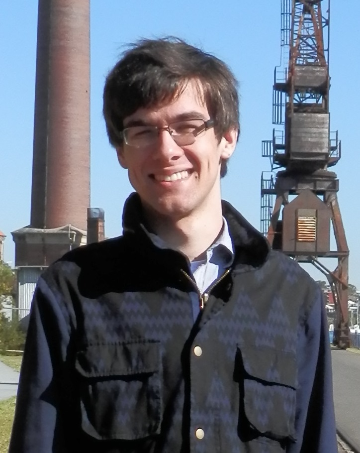

# Zoom etiquette (subjecct to change as we figure this out)

- Leave your video off
- Stay muted unless asking a question - there are 40-50 of us here, and we don’t want to be interrupted by background noise
- To ask a question, type the word “question” in the chat and wait for me to call on you
- Please email me feedback after lectures! When lecturing, I can usually get a feel for whether or not people are engaged, confused or bored from body language. Since I can’t see you, I’m relying on you to tell me.

# What is R?

- A scripting language designed specifically for statistical data analysis

## What are it’s strengths?

- The syntax and logic are uniquely suited for statistics analysis - though somewhat quirky, it allows you to express common statistical ideas clearly and succinctly, where this might be awkward in (say) python’s `sklearn` or `statsmodels`
- A huge ecosystem of statistical and data-analytic libraries and packages with excellent documentation that usually includes mathematical explanations and justifications of procedures (a rare find!)
- Beautiful and flexible data visualisation tools in `ggplot` and relatives
- A (relatively) recently modernised interface in the `tidyverse`, which is the focus of this course
- Great for writing up analysis through RMarkdown - all lecture slides will be written this way!

```r
print("Hello, world!")
```

```
## [1] "Hello, world!"
```

## What are you better off finding elsewhere?

- Processing really big datasets - R is not a computational beast, and is best suited to medium-sized datasets. For efficiency and parallelisation, you probably want something like Hadoop
- Big-ol tensor multiplication - if you’re training neural networks, TensorFlow is the way to go
- Automating regular tasks - R is a domain-specific programming language, and while it can technically do anything that a general-purpose language can do, the results are invariably horrifying

# Administrative details

- The [course website](http://web.stanford.edu/class/stats32/) is the comprehensive guide to all things procedural
- **Lectures:** Weeks 2-5, April 13 to May 7, TTh 12:00 - 1:20pm
- **Office hours:** Weeks 1-6, April 8 to May 13, W 9:00 - 11:00am
- **Grading:** Credit/no credit basis
  - Final project (80%), due May 16
  - Final project proposal (20%), due May 1
  - Much more detail can be found on the [course website](http://web.stanford.edu/class/stats32/project/)
- While not using a specific textbook, the course runs parallel to Hadley Wickham’s free online book [R for Data Science](https://r4ds.had.co.nz/). It’s very accesibly written, and I encourage you to read as much of it as you can!
- In the current climate, things can change unexpectedly, so please monitor the [course changes](http://web.stanford.edu/class/stats32/distance/) page closely

# Structure of the course

**Before the session**

- Read the assigned and suggested texts - you will get much more out of each lecture if you do this!

**During the session**

- We look at a motivating example arising from a real dataset
- I present the relevant theory and technical details
- I do a demonstration of coding/workflow that leads to that motivating example

**After the session**

- Do the assigned programming questions (these will not be graded, but will address details and subtelties that we don’t have time for in lecture)
- Play around with the session’s dataset!

# List of useful packages

- `dplyr`: Transform data
- `ggplot2`: Make nice plots
- `readr`: Import data into R
- `tidyr`: Clean data
- `stringr`: Tools for working with character strings and regular expressions
- `lubridate`: Make working with dates and times easier
- `caret`: Tools for training regression and classification models
- `maps`, `ggmap`: Tools for plotting spatial data
- `shiny`: Make interactive web apps

# Other fun R stuff

- [R shiny dashboard](https://sjfmarks.shinyapps.io/nba_shiny_dash/) for correlations between various stats for NBA 2017-18 season
- [Making XKCD-like graphs](http://xkcd.r-forge.r-project.org/)
- [Animated plots](https://towardsdatascience.com/animating-your-data-visualizations-like-a-boss-using-r-f94ae20843e3) using various R packages
- [Visualizations projected on the earth as a globe](https://www.displayr.com/interactive-globe-r/)
- [Visualizing soccer world cup goals](https://ryo-n7.github.io/2018-06-29-visualize-worldcup/)

# [R-bloggers](https://www.r-bloggers.com/)

Blog aggregator of content contributed by bloggers who write about R

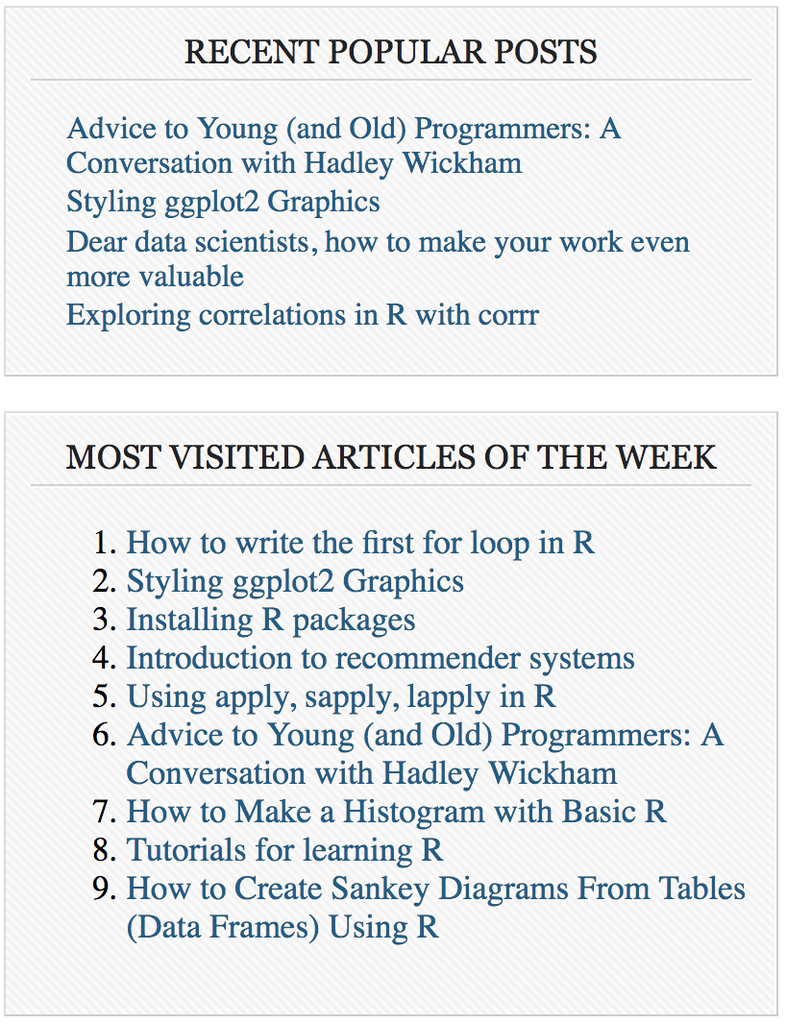

[figure not shown]

# [The R Journal](https://journal.r-project.org/)

Bi-annual open-access journal: Features short to medium length articles covering topics of interest to R users and developers

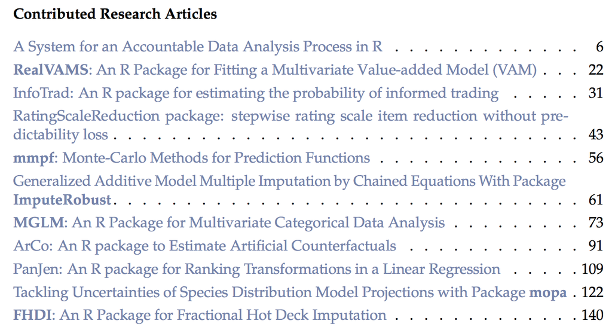

# [R-exercises](http://www.r-exercises.com/start-here-to-learn-r/)

Website with both tutorials and exercises

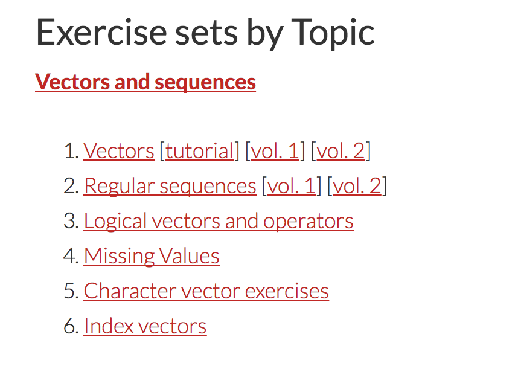

[figure not shown]

# [DataCamp](https://www.datacamp.com/)

Website for learning data science, R included (some courses free, some not)

[figure not shown]

# Let’s get our hands dirty!

**Today’s dataset:** Uber and Green taxi trips in New York

- `rides.csv`: Time, location, duration, etc. of rides made in Uber and Green taxi cabs in 2014 and 2015
- `weather.csv`: Temperature, precipitation, snowfall, etc. in New York in 2014 and 2015

**Some questions**

- How do rides in the two companies compare?
- How does demand change in space and time?
- Does weather affect cab rides? If so, by how much? And is the effect different for different companies?